# Occupational Mobility June 2022

Ken-Hou Lin

25 June, 2022

# Overview

This memo documents the new things we have looked into since our last meeting, including using different sources of data to observe the mobility pattern, comparing between- and within-employer mobility, and comparing gender differences in the association between co-presence and mobility.

# The Three Data Sources

All our previous results were generated using CPS-ASEC (March Supplement). It has a nice dependent coding structure that ensure the occupational changes are not due to inconsistent coding. Another benefit is that the information about the before and after occupations is collected at one time point and by the same interviewer. We do not have to worry about attrition. A common criticism is that the mobility in ASEC does not reflect yearly mobility, but 4-month mobility, which isn’t really an issue for us.

The second possible source is to use the monthly data. CPS households are interviewed monthly for 4 consecutive months, rotated out for 8 months, and re-interviewed for another 4 consecutive months. We use the consecutive interviews to construct month-to-month transition for three main reasons. First, month-to-month, instead year-to-year transition would give us more data points, which is important because CPS monthly sample is smaller than the ASEC/March supplement sample. Second, the attrition issue is more severe when linking individuals before and after the 8-month pause. Third, yearly mobility is best captured by the mobility supplement.

Since individuals will leave the sample if they leave the household, attrition is a potential issue. The main benefit of using the monthly data is that there is an item asking if the individual changed their employer.

The third possible source is the mobility supplement, which contrasts current occupation with the occuptation from a year ago. According to Anne Polivka, it is the best source for constructing between-occupation mobility patterns. However, Koit noticed some inconsistencies among the items in the supplement. The staff at the IPUMS told us that they were aware of the issue but did not have a timeline regarding when it could be resolved.

For now, we have a mobility measure using the supplement, which we are not entirely confident of. We are still waiting for IPUMS to update us about how to proceed.

## Mobility Rates

```r
pair<-read_dta("CPS_OES.dta")

measures <-subset(pair,select=c(exp,flow,flow_mly,flow_supp))
apply(measures[,2:4],2,mean)
```

```
##         flow     flow_mly    flow_supp
## 0.0005674565 0.0002314263 0.0002225306
```

We first check the mobility rate by each measure. The average ASEC mobility rate is higher than the average monthly rate, which makes sense, since ASEC reflects longer-term mobility than the monthly data. However, it is rather strange than the supplement mobility rate is lower than the other two measures, when it’s supposed to be the highest (a full year). I am not sure how to think about this. Hopefully we will hear from IPUMS soon.

## Correlation

Next, the correlation among the three measures and the co-presence variable:

```r
cor(measures)
```

```
##                 exp      flow  flow_mly flow_supp
## exp       1.0000000 0.2444228 0.4778008 0.2975819
## flow      0.2444228 1.0000000 0.4175161 0.2281753
## flow_mly  0.4778008 0.4175161 1.0000000 0.3966827
## flow_supp 0.2975819 0.2281753 0.3966827 1.0000000
```

In general, everything is positively correlated with each other. The co-presence measure is most strongly correlated with monthly mobility. The ASEC measure is more strongly correlated with the monthly measure than the Supplement measure.

I also did some regression analysis using the three measures. The results are quite similar. Co-presence has the largest standardized coefficient when using the monthly measure. **Overall, the substantive findings seem pretty insensitive to which measure we use.**

Since I am not sure if the supplement measure (we have at this point) is reliable, below I will replicate our previous results using the monthly measure. It also allows me to explore some new directions.

# Mobility & Co-presence

I will start by examining the correlation between co-presence and monthly mobility. Some of these results probably don’t need to be in the paper.

### By Mobility Type

I separate all dyads into three types of mobility:

- Downward: Destination median wage is lower than 90% of the origin median wage.
- Lateral: Destination median wage is between 90% and 110% of the origin median wage.
- Upward: Destination median wage is higher than 110% of the origin median wage.

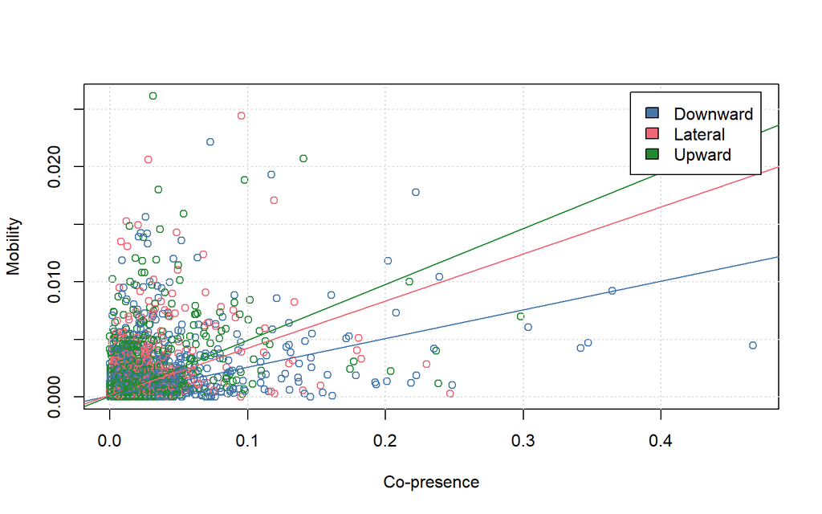

```r
pair<-read_dta("CPS_OES.dta")


pair$col<-0
pair$col[pair$mob_type==1]<-1
pair$col[pair$mob_type==2]<-2
pair$col[pair$mob_type==3]<-3
plot(pair$exp,pair$flow_mly,xlab="Co-presence",ylab="Mobility",col=pcolor1[pair$col])
grid()

down<-subset(pair,pair$col==1)
lat<-subset(pair,pair$col==2)
up<-subset(pair,pair$col==3)

d_reg<-lm(flow_mly ~ exp, data = down,w=sendsize_mly)
l_reg<-lm(flow_mly ~ exp, data = lat,w=sendsize_mly)
u_reg<-lm(flow_mly ~ exp, data = up,w=sendsize_mly)

abline(d_reg, col=pcolor1[1])
abline(l_reg, col=pcolor1[2])
abline(u_reg, col=pcolor1[3])

legend("topright",c("Downward","Lateral","Upward"),inset=0.025, fill=pcolor1[c(1:3)])
```

The pattern confirms previous findings that co-presence is least correlated with mobility when facing an occupation with a significantly lower median wage. The correlation is strongest for upward mobility.

# Model Estimates

## Main Model

I estimate the following model:

$$F_{i->j}=O_{i->j}+|D_{i}-D_{j}|+C_{j}+|S_{i}-S_{j}|$$

Where $F_{i->j}$ denotes the directional flow from Occupation i to Occupation j, measured as the number of workers in Occupation j at t+1 over the number of workers in Occupation i at t. $O_{i->j}$ denotes the proportion of co-workers of people in Occupation i are in Occupation j.

$D$ captures the absolute difference between i and j in % of workers who are men and % White. They should be negatively correlated with mobility.

$C$ captures educational credentialing and licensure of the destination that facilitate social closure, including the absolute difference in the average years of education and % workers reporting their jobs require a license.

$S$ captures the absolute differences in a variety of general skill requirements, including Quantitative, Analytic, Creative, Interactive, Supervisory, Spatial, and Motion Control. All skill measures are standardized so each unit represents one standard deviation. This is more so a kitchen sink approach, clearly. I do not include Verbal skill because it’s highly correlated with educational difference.

An obvious complication when estimating a regression with our data set is that the observations are non-independent. I will report two “P-values.” The first is with origin clustered SE. The second is a percentile generated using the QAP procedure with 1,000 iterations/bootstraps, where values >0.95 or <0.05 indicate statistical significance. The two yield quite similar results.

```r
t1<-read.csv("table_all.csv")
qap<-read_dta("dist_qap_all.dta")
qap<-as.matrix(qap)
coef<-read_dta("coef_all.dta")
coef<-as.numeric(coef[1,])

t1<-cbind(t1,NA)
colnames(t1)<-c("Variable","Coefficent","Clstr SE P-value","QAP Percentile")


lab<-c("% Male"," % White","Average Yr EDUC","% Licenced",
       "Quantiative","Analytic","Creative","Interactive","Supervisory",
       "Spatial","Control")
loc<-2+length(lab)
t1[2:loc,1]<-c("Co-presence",lab)

for (i in 1:12){
  percentile <- ecdf(qap[,i])
  ptile<-percentile(coef[i])
  t1[i+1,4]<-ptile
}


knitr::kable(t1)
```

| Variable | Coefficent | Clstr SE P-value | QAP Percentile |
| --- | --- | --- | --- |
| = | =flow_mly | = | NA |
| Co-presence | =0.0303*** | =(0.000) | 1.000 |
| % Male | =-0.000340*** | =(0.000) | 0.000 |
| % White | =-0.0000595 | =(0.198) | 0.292 |
| Average Yr EDUC | =-0.0000441*** | =(0.000) | 0.000 |
| % Licenced | =-0.000104*** | =(0.000) | 0.050 |
| Quantiative | =-0.0000358*** | =(0.000) | 0.005 |
| Analytic | =0.0000139 | =(0.126) | 0.769 |
| Creative | =-0.0000262*** | =(0.000) | 0.032 |
| Interactive | =-0.00000680 | =(0.375) | 0.304 |
| Supervisory | =-0.0000406*** | =(0.000) | 0.002 |
| Spatial | =-0.00000411 | =(0.657) | 0.391 |
| Control | =-0.0000338*** | =(0.000) | 0.019 |
| =_cons | =0.000498*** | =(0.000) | NA |
| =N | =34782 | = | NA |
| =R-sq | =0.251 | = | NA |
| =p-values in parentheses |  |  | NA |
| =* p<0.05, ** p<0.01, *** p<0.001 |  |  | NA |

The estimates here are mostly consistent with the expectation. We see that co-presence is correlated with higher mobility net of a battery of control variables.

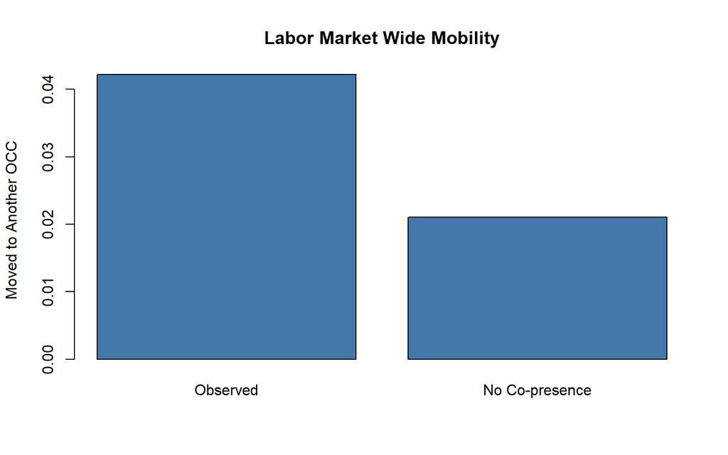

```r
cf<-read_dta("counterfactual_all.dta")


ob<-weighted.mean(cf$ob, cf$sendsize_mly)


noexp<-weighted.mean(cf$cf_exp, cf$sendsize_mly)
dif<-ob-noexp



barplot(cbind(ob,noexp),
        col=pcolor1,names.arg = c("Observed","No Co-presence")
        ,ylab="Moved to Another OCC ",
         main="Labor Market Wide Mobility")
```

Here we see a significant decline in labor market wide mobility if all occupations are isolated. The decline is about 50.082 % of the total observed mobility, which I find quite substantial and can be a key finding. I would love to hear your thought/reaction about this.

### Occupational Similarities

It is possible that the co-presence is driven by occupational similarities that are not captured by the general skill measures. To test this possibility, we incorporate two additional controls from O*NET. The first is knowledge cosine, describing to what extent the two occupations share the same domain-specific knowledge. The second is relatedness, describing how similar the work content and activities are between a pair of occupations. Both are expected to be positively associated with mobility and attenuate the coefficients we saw in the previous table.

To be clear, since learning domain-specific knowledge could be a consequence of working in the same workplace, it could be understood as a mediator instead of a confounder.

```r
t1<-read.csv("table_all_relate.csv")
qap<-read_dta("dist_qap_all_relate.dta")
qap<-as.matrix(qap)
coef<-read_dta("coef_all_relate.dta")
coef<-as.numeric(coef[1,])

t1<-cbind(t1,NA)
colnames(t1)<-c("Variable","Coefficent","Clstr SE P-value","QAP Percentile")


lab<-c("% Male"," % White","Average Yr EDUC","% Licenced",
       "Quantiative","Analytic","Creative","Interactive","Supervisory",
       "Spatial","Control","Knowledge","Relatedness")
loc<-2+length(lab)
t1[2:loc,1]<-c("Co-presence",lab)

for (i in 1:14){
  percentile <- ecdf(qap[,i])
  ptile<-percentile(coef[i])
  t1[i+1,4]<-ptile
}


knitr::kable(t1)
```

| Variable | Coefficent | Clstr SE P-value | QAP Percentile |
| --- | --- | --- | --- |
| = | =flow_mly | = | NA |
| Co-presence | =0.0266*** | =(0.000) | 1.000 |
| % Male | =-0.000156*** | =(0.000) | 0.000 |
| % White | =-0.0000523 | =(0.217) | 0.332 |
| Average Yr EDUC | =-0.0000118* | =(0.018) | 0.127 |
| % Licenced | =-0.0000767** | =(0.006) | 0.113 |
| Quantiative | =-0.0000221*** | =(0.000) | 0.058 |
| Analytic | =0.0000160 | =(0.099) | 0.802 |
| Creative | =-0.00000930 | =(0.075) | 0.257 |
| Interactive | =0.0000245** | =(0.009) | 0.956 |
| Supervisory | =-0.0000589*** | =(0.000) | 0.000 |
| Spatial | =0.00000916 | =(0.319) | 0.714 |
| Control | =-0.00000246 | =(0.759) | 0.438 |
| Knowledge | =-0.000670* | =(0.022) | 0.202 |
| Relatedness | =0.000241*** | =(0.000) | 1.000 |
| =_cons | =0.000870** | =(0.001) | NA |
| =N | =34410 | = | NA |
| =R-sq | =0.284 | = | NA |
| =p-values in parentheses |  |  | NA |
| =* p<0.05, ** p<0.01, *** p<0.001 |  |  | NA |

The inclusion of these two additional measures does attenuate the coefficient for co-presence but the latter is still robustly correlated with mobility.

## By Mobility Type

As discussed above, the effect of co-presence is likely to vary by mobility. I therefore modify the previous equation and add both mobility type $T_{i->j}$ and its interaction with co-presence:

$$F_{i->j}=O_{i->j}+T_{i->j}+O_{i->j}*T_{i->j}+|D_{i}-D_{j}|+C_{j}+|S_{i}-S_{j}|$$

```r
t1<-read.csv("table_by_mob.csv")
qap<-read_dta("dist_qap_mob.dta")
qap<-as.matrix(qap)
coef<-read_dta("coef_mob.dta")
coef<-as.numeric(coef[1,-c(2,5)])
t1<-t1[-c(1,3,6),]
row.names(t1) <- NULL

t1<-cbind(t1,NA)
colnames(t1)<-c("Variable","Coefficent","Clstr SE P-value","QAP Percentile")


lab<-c("Co-presence","Lateral","Upward","Co-presence*Lateral","Co-presence*Upward",
       "% Male"," % White","Average Yr EDUC","% Licenced",
       "Quantiative","Analytic","Creative","Interactive","Supervisory",
       "Spatial","Control")
loc<-length(lab)
t1[1:loc,1]<-c(lab)

for (i in 1:loc){
  percentile <- ecdf(qap[,i])
  ptile<-percentile(coef[i])
  t1[i,4]<-ptile
}


knitr::kable(t1)
```

| Variable | Coefficent | Clstr SE P-value | QAP Percentile |
| --- | --- | --- | --- |
| Co-presence | =0.0233*** | =(0.000) | 1.000 |
| Lateral | =0.0000233 | =(0.465) | 0.833 |
| Upward | =-0.0000163 | =(0.373) | 0.227 |
| Co-presence*Lateral | =0.0154* | =(0.049) | 1.000 |
| Co-presence*Upward | =0.0219*** | =(0.000) | 1.000 |
| % Male | =-0.000321*** | =(0.000) | 0.000 |
| % White | =-0.0000506 | =(0.238) | 0.326 |
| Average Yr EDUC | =-0.0000415*** | =(0.000) | 0.000 |
| % Licenced | =-0.000123*** | =(0.000) | 0.020 |
| Quantiative | =-0.0000357*** | =(0.000) | 0.004 |
| Analytic | =0.0000229** | =(0.010) | 0.899 |
| Creative | =-0.0000237*** | =(0.000) | 0.046 |
| Interactive | =-0.00000876 | =(0.222) | 0.248 |
| Supervisory | =-0.0000400*** | =(0.000) | 0.003 |
| Spatial | =-0.00000250 | =(0.780) | 0.433 |
| Control | =-0.0000347*** | =(0.000) | 0.015 |
| =_cons | =0.000470*** | =(0.000) | NA |
| =N | =34782 | = | NA |
| =R-sq | =0.271 | = | NA |
| =p-values in parentheses |  |  | NA |
| =* p<0.05, ** p<0.01, *** p<0.001 |  |  | NA |

The estimates here are consistent with the expectation that co-presence has stronger effect for upward mobility.

I can also estimate separate models for each type of mobility but I won’t be able to produce QAP estimates for non-square matrices.

We can now conduct a similar analysis to see how much co-presence attributes to each type of mobility.

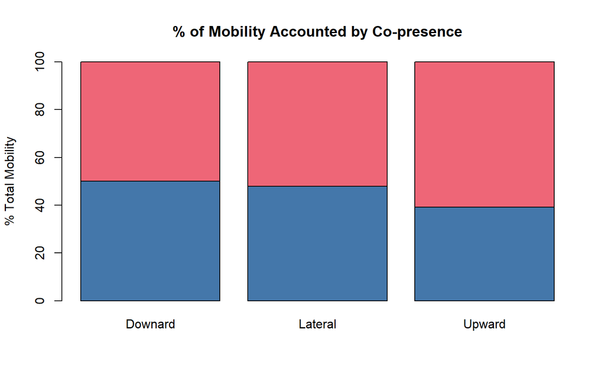

```r
cf1<-read_dta("counterfactual_1.dta")
cf2<-read_dta("counterfactual_2.dta")
cf3<-read_dta("counterfactual_3.dta")

ob1<-weighted.mean(cf1$ob, cf1$sendsize)
noexp1<-weighted.mean(cf1$cf_exp, cf1$sendsize)
dif1<-ob1-noexp1

ob2<-weighted.mean(cf2$ob, cf2$sendsize)
noexp2<-weighted.mean(cf2$cf_exp, cf2$sendsize)
dif2<-ob2-noexp2

ob3<-weighted.mean(cf3$ob, cf3$sendsize)
noexp3<-weighted.mean(cf3$cf_exp, cf3$sendsize)
dif3<-ob3-noexp3

m<-matrix(c(1-dif1/ob1,dif1/ob1,1-dif2/ob2,dif2/ob2,1-dif3/ob3,dif3/ob3),byrow=F,ncol=3)

barplot(m*100,
        col=pcolor1[1:2],names.arg = c("Downard","Lateral","Upward"),ylab="% Total Mobility", ylim=c(0,100), main="% of Mobility Accounted by Co-presence")
```

The figure shows that co-presence accounts for 49.979 % of total downward mobility, 52.092 % of total lateral mobility, and 60.876 % of total upward mobility. I think these are pretty large numbers.

## Between and Within Mobility

Occupational mobility can unfold either within the same employer or between employers. The former is related to workplace arrangements, while the latter is more associated with individuals acquiring new aspirations and skills. It is therefore informative to see how co-presence may associate with between- and within-employer occupational mobility differently.

The model is similar to the one before but we distinguish within-employer occupational mobility from between-employer occupational mobility:

$$F_{i->j,e}=O_{i->j}+E_{i-j,e}+O_{i->j}*E_{i->j,e}+|D_{i}-D_{j}|+C_{j}+|S_{i}-S_{j}|$$

where $E$ indicates if it’s within- or between-employer mobility. Notice that the co-presence variable and all controls are constant for each combination of $i$ and $j$ and do not vary by these two types of mobility. Thus, we can also fit a fixed-effect model to contrast the two types of mobility:

$$F_{i->j,e}=\alpha_{i->j}+E_{i-j,e}+O_{i->j}*E_{i->j,e}$$

where $\alpha_{i->j}$ denotes the fixed effects.

```r
t1<-read.csv("table_bw.csv")
t1<-t1[-c(1,3,5),]
row.names(t1) <- NULL

colnames(t1)<-c("Variable","Coeff.","P","Coeff.","P")


lab<-c("Co-presence","Within Emp.","Co-presence*Within",
       "% Male"," % White","Average Yr EDUC","% Licenced",
       "Quantiative","Analytic","Creative","Interactive","Supervisory",
       "Spatial","Control")
loc<-length(lab)
t1[1:loc,1]<-c(lab)




knitr::kable(t1)
```

| Variable | Coeff. | P | Coeff. | P |
| --- | --- | --- | --- | --- |
| Co-presence | =0.00504*** | =(0.000) | =0 | =(.) |
| Within Emp. | =-0.00000996*** | =(0.000) | =-0.00000996*** | =(0.001) |
| Co-presence*Within | =0.00274*** | =(0.000) | =0.00274*** | =(0.000) |
| % Male | =-0.0000769*** | =(0.000) | = | = |
| % White | =-0.0000156 | =(0.102) | = | = |
| Average Yr EDUC | =-0.0000107*** | =(0.000) | = | = |
| % Licenced | =-0.0000263*** | =(0.000) | = | = |
| Quantiative | =-0.00000858*** | =(0.000) | = | = |
| Analytic | =0.00000243 | =(0.235) | = | = |
| Creative | =-0.00000491*** | =(0.000) | = | = |
| Interactive | =-0.00000224 | =(0.177) | = | = |
| Supervisory | =-0.00000937*** | =(0.000) | = | = |
| Spatial | =-0.00000164 | =(0.345) | = | = |
| Control | =-0.00000772*** | =(0.000) | = | = |
| =_cons | =0.000128*** | =(0.000) | =0.0000553*** | =(0.000) |
| =N | =69564 | = | =69564 | = |
| =R-sq | =0.223 | = | =0.828 | = |
| =p-values in parentheses |  |  |  |  |
| =* p<0.05, ** p<0.01, *** p<0.001 |  |  |  |  |

The coefficients here show that when individual workers changed employers, they were more likely to change occupations (The Within-Emp coefficient is negative). Yet, co-presence remains predictive of which occupation they moved to (The Co-presence coefficient is positive). The effect of co-presence is stronger for occupational movers who stayed with the same employer(Co-presence*Within coefficient is positive in both models).

The results here suggest that both individual learning and organization arrangement are in play between co-presence and mobility.

## Comparing Men and Women

Another thing to consider is if co-presence has different effects between men and women.

```r
weighted.mean(pair$flow_mly_men,w=pair$sendsize_mly_men)
```

```
## [1] 0.0002375144
```

```r
weighted.mean(pair$flow_mly_women,w=pair$sendsize_mly_women)
```

```
## [1] 0.0002140696
```

Men have a slightly higher transition rate than women.

```r
sex_type<-matrix(rep(0,6),ncol=2)
rownames(sex_type)<-c("Downward","Lateral","Upward")
colnames(sex_type)<-c("Men","Women")

for(i in 1:3){
  sex_type[i,1]<-weighted.mean(pair$flow_mly_men [pair$mob_type==i],
                w=pair$sendsize_mly_men [pair$mob_type==i])
  sex_type[i,2]<-weighted.mean(pair$flow_mly_women[pair$mob_type==i],
                w=pair$sendsize_mly_women[pair$mob_type==i])
}


knitr::kable(sex_type)
```

|  | Men | Women |
| --- | --- | --- |
| Downward | 0.0002000 | 0.0002173 |
| Lateral | 0.0003874 | 0.0003220 |
| Upward | 0.0002288 | 0.0001815 |

Men have lower downward mobility and higher lateral and upward mobility than women.

We can estimate the same fixed-effect model to see if co-presence has greater effects for men or women for a given mobility pathway.

```r
t1<-read.csv("table_sex.csv")
t1<-t1[-c(1),]
row.names(t1) <- NULL

colnames(t1)<-c("Variable","All","P","Downward","P",
                "Lateral","P","Upward","P")

lab<-c("Women","Women*Co-Presence")
loc<-length(lab)
t1[1:loc,1]<-c(lab)

knitr::kable(t1)
```

| Variable | All | P | Downward | P | Lateral | P | Upward | P |
| --- | --- | --- | --- | --- | --- | --- | --- | --- |
| Women | =-0.0000137 | =(0.060) | =0.0000355* | =(0.019) | =-0.0000173 | =(0.362) | =-0.0000435*** | =(0.000) |
| Women*Co-Presence | =0.000799 | =(0.614) | =0.00409 | =(0.127) | =-0.00233 | =(0.653) | =-0.0107** | =(0.003) |
| =_cons | =0.000232*** | =(0.000) | =0.000184*** | =(0.000) | =0.000370*** | =(0.000) | =0.000243*** | =(0.000) |
| =N | =69564 | = | =29698 | = | =9730 | = | =30136 | = |
| =R-sq | =0.890 | = | =0.864 | = | =0.911 | = | =0.905 | = |
| =p-values in parentheses |  |  |  |  |  |  |  |  |
| =* p<0.05, ** p<0.01, *** p<0.001 |  |  |  |  |  |  |  |  |

## Co-presence and Skill Gaps

The last set of analysis focuses on how the effect of co-presence could be contingent on occupational differences. We would expect that the effect of co-presence to be higher when the occupations are more similar and lower when the occupations are less similar. The dissimilarity could be so large that renders co-presence irrelevant. I think it would be interesting to see at what point co-presence no longer promotes mobility but I am curious about whether you find it interesting/meaningful.

Essentially, I plan to add interaction terms between co-presence and each skill difference to allow the association between co-presence and mobility to vary by skill difference (or vice versa). I will then plot the predicted flows of having zero co-presence and that of having 10 percent of workers by skill difference, from no difference to 4 standard deviation of difference.

I will focus only on upward mobility for this set of analysis due to its importance and the ease of interpretation (skill difference tends to mean deficiency, not excess, in comparison to the destination occupation).

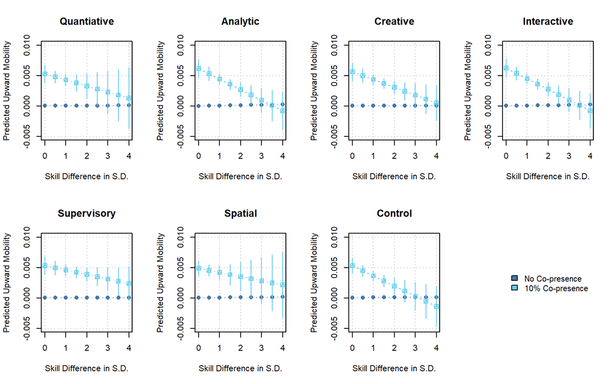

```r
est<-read_dta("inter_estimates.dta")
m<-as.matrix(est)
lab<-c("Quantiative","Analytic","Creative","Interactive","Supervisory",
       "Spatial","Control")

xcord<-seq(0,4,0.5)

par(mfrow=c(2,4))
k<-1
for (i in seq(1,25,4)){
j<-i+2
plot(xcord,m[,i],type="b",pch=16,
     ylim=c(-0.005,0.01),
     xlab="Skill Difference in S.D.",ylab="Predicted Upward Mobility",main=lab[k])
grid()
points(xcord,m[,i],type="b",pch=16,col=pcolor1[1])
points(xcord,m[,j],type="b",pch=14,col=pcolor1[5])
segments(xcord,m[,i]+1.96*m[,i+1],xcord,m[,i]-1.96*m[,i+1],col=pcolor1[1])
segments(xcord,m[,j]+1.96*m[,j+1],xcord,m[,j]-1.96*m[,j+1],col=pcolor1[5])
box()
k<-k+1
}

plot.new()
legend("center",c("No Co-presence","10% Co-presence"),
       fill=c(pcolor1[1],pcolor1[5]),bty="n",cex=0.95)
```

The “No Co-presence” estimates do have error bars but they are very small because there are many observations with a co-presence of zero.

Second, skill differences do not move mobility much when there is no co-presence. That is, in the absence of co-presence, no matter how big or small the skill difference is, the mobility is always close to zero.

This is a rather interesting outcome to me because it shows that firms may be fundamental to skill differentiation and sorting. Even if the origin and destination occupations have very similar skill contents, there would not be much upward mobility unless the two occupations situated in same workplaces.

# Conclusion

- Among the three data sources, it seems that we should use month-to-month as the main data source and the other two as robustness test, mostly because we know if people changed employers with the monthly data.
- The between- and within-employer findings are important because they show that the co-presence is not simply the employer moving people around different occupations. Individuals seem to get something and are able to obtain a different occupation from a different employer.
- While the gender difference is interesting, I am not sure how we can explain the difference. Is it mostly about supply side difference? Women are discriminated against for promotion? It would probably take up a good amount of space to think about the gender difference properly.